# MNC Cell Line

### At most 20% missing per protein, 10% pseudo NA introduced.

We filter the original data to have at most 20% of its entries per protein as NA values. We then randomly choose 10% of the present intensities and replace them with NA values. Our imputed dataset has 127 proteins in total. Below we see the distribution of the differences between the imputed (pseudo NA) values and the original values.

The mean squared error between the imputed pseudo NA values and the original values is 1.8055884.

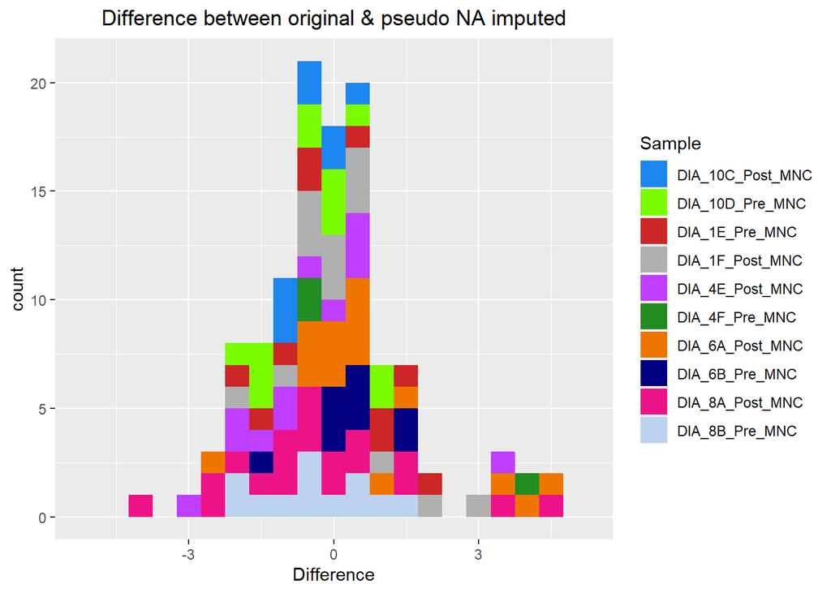

```r
p1
```

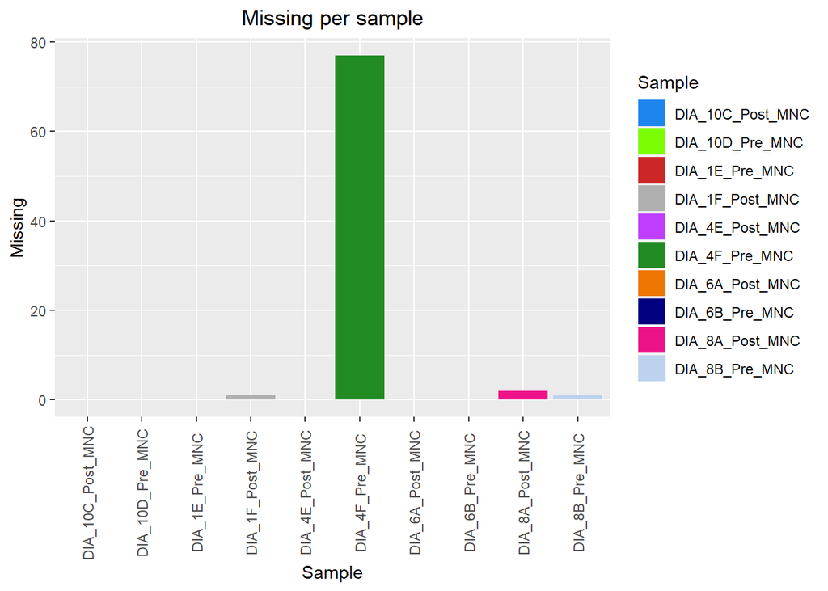

```r
p2
```

### At most 40% missing per protein, 10% pseudo NA introduced.

We filter the original data to have at most 40% of its entries per protein as NA values. We then randomly choose 10% of the present intensities and replace them with NA values. Our imputed dataset has 372 proteins in total. Below we see the distribution of the differences between the imputed (pseudo NA) values and the original values.

The mean squared error between the imputed pseudo NA values and the original values is 1.7557904.

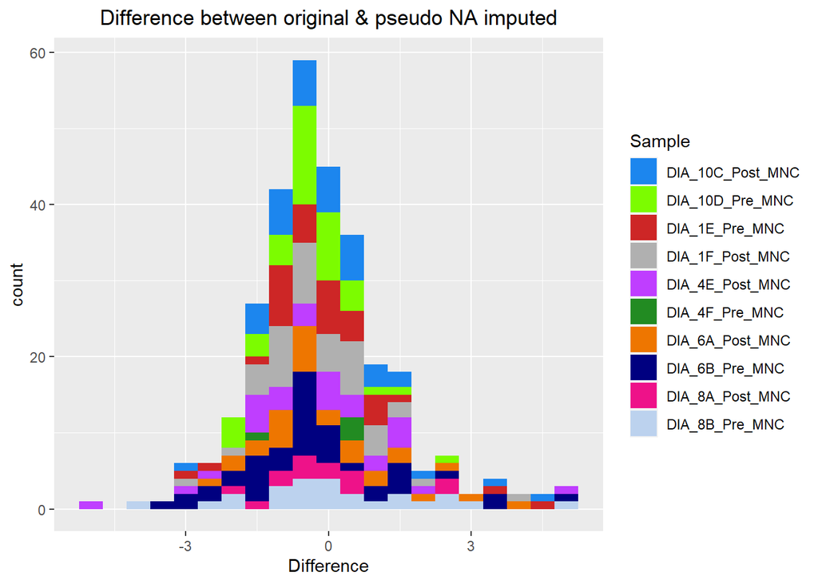

```r
p1
```

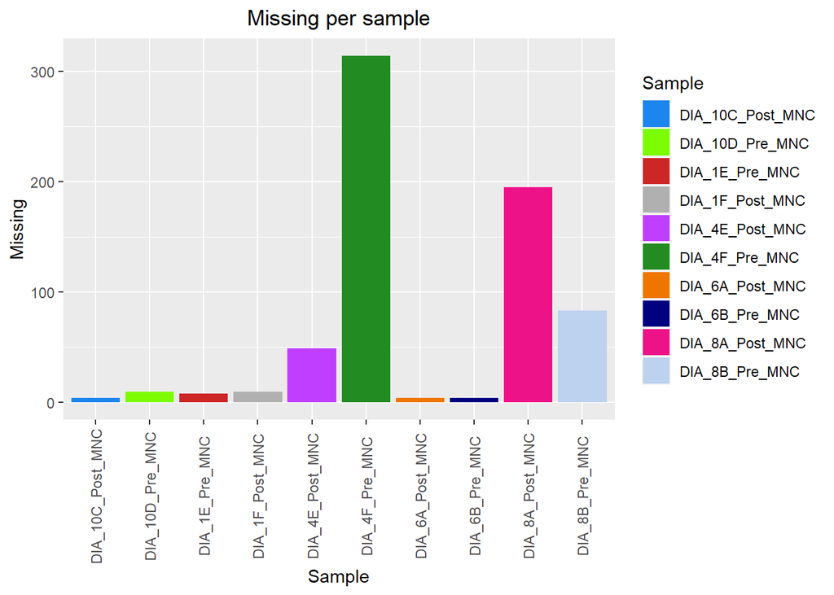

```r
p2
```

### At most 60% missing per protein, 10% pseudo NA introduced.

We filter the original data to have at most 60% of its entries per protein as NA values. We then randomly choose 10% of the present intensities and replace them with NA values. Our imputed dataset has 578 proteins in total. Below we see the distribution of the differences between the imputed (pseudo NA) values and the original values.

The mean squared error between the imputed pseudo NA values and the original values is 1.6779314.

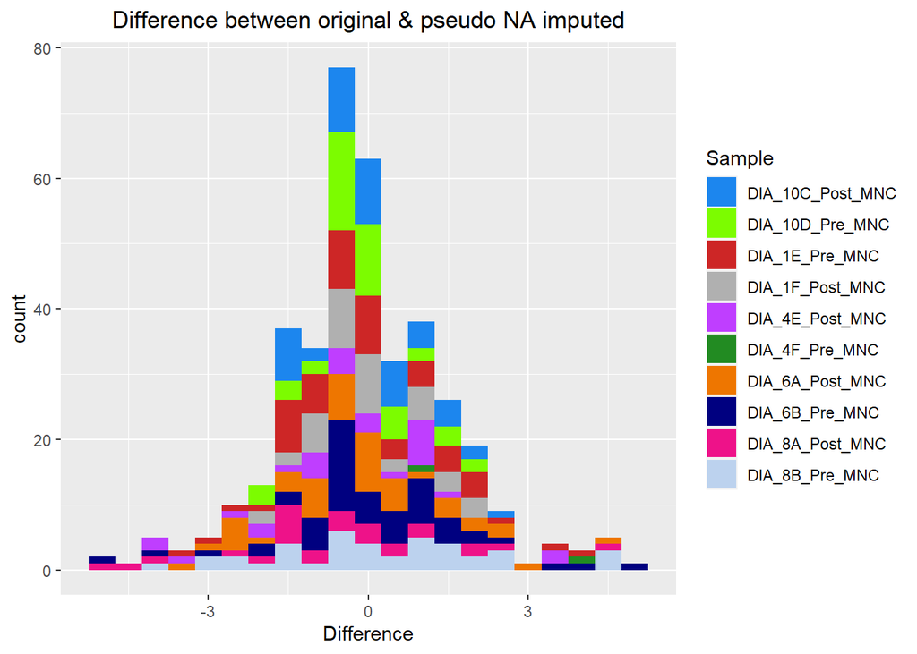

```r
p1
```

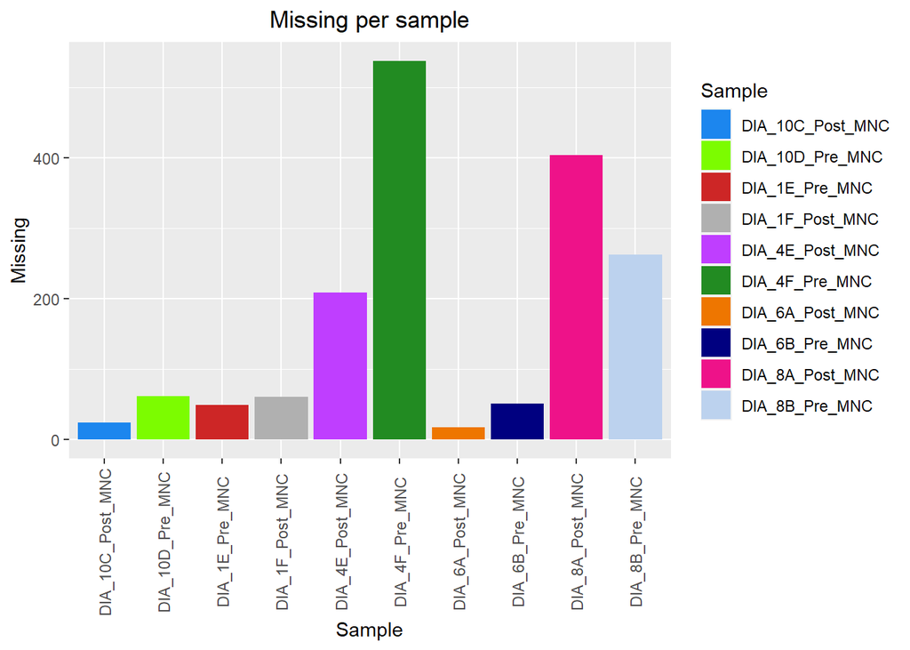

```r
p2
```